# other resources

http://library.queensu.ca/ojs/index.php/IEE/article/view/4608  
http://www.rstudio.com/wp-content/uploads/2015/02/data-wrangling-cheatsheet.pdf

# Data Cleaning, Management and Manipulation

If you talk to people who hate R chances are (if they have used R) the reason they hate it has nothing to do with R, and EVERYTHING to do with data management.

R is not excel, it will never be excel, and for that we can all be grateful. But if the only way you have ever interacted with data is through excel obviously R is a totally different ballgame.

One of the big complaints I hear is ‘R doesn’t read excel files’

- first - this is not true (there are packages that let you read in excel files)
- second - if you have your data in a CLEAN AND MANAGED FORM you can save your excel file as a txt or csv or tsv and EASILY import it into R.
- third - people like to hate on R (just like I love to love on R)

*There are many things you can do AS YOU ENTER *and* PROOF your data to make your life easier (EVEN IF YOU DONT USE R)*

Ideally you will do all your data analysis of one dataset *without* splitting the dataset up into little pieces

### tips for getting data into R without wanting to destroy things

- NO SPACES *especially in column headers*
- do not start column headers with numbers
- keep EVERYTHING LOWER CASE unless you have a really good reason
- you CAN use underscores “_" or periods “.” but really running things together *intooneword* is better

### Talk about metadata and why scripting data cleaning/management is a *great* idea.

- good metadata - your most important collaborator is yourself six months ago, so leave yourself good notes, since you can’t send yourself six months ago an email. You and anyone who uses your data/code later on with thank you.

### Data Cleaning in R

- read your data into R
  - sometimes this is an entire excercise in and of itself if you have ever been given a dataset that is spread across X number of spreadsheets
  - IF you can get all the spreadsheets into excel, script your process of hooking them together. First you want to clean each one individually and then use some of the techniques below to stitch them together into one big file
- look at the structure, make sure R read things in the way you think (numbers are numbers especially)
- chances are if R read something in ‘wrong’ then there is somethign funky in your data (like some letters in a numeric column)
- now look for impossible and improbable data. Often the easiest way to do this is the summary() function and check the max/min and see if either is impossible or improbable. Deal with those accordingly.
- this is more difficult for factors, the unique() function can be helpful for you to visually assess if you have any *slightly different* factors (mingoNWR vs MingoNWR) and you can edit accordingly
- all of these changes should be made in R, and shoudl be scripted, and written out to a new clean file
- DO NOT CHANGE THE RAW DATA
- Save your scripts for data cleaning/data manipulation and if you remove any part of the data make comments within the script explaining why so that future you can remember, future you is an idiot, comment accordingly

```r
# subsettting data
library(tidyr)
library(dplyr)
library(ggplot2)
library(gapminder)
```

# DPLYR

### pipes

often when doing data management you want to do a series of things to a data frame, without having each thing you do assigned to a new, or constantly over writing object. One way you can do this is with pipes %>% which are part of the tidyr and dplyr packages. So you can load either package to get pipes.

```r
data(gapminder)

gdat <- gapminder
# this is also super helpful for looking at the top of a file

gdat %>% head
```

```
##       country continent year lifeExp      pop gdpPercap
## 1 Afghanistan      Asia 1952  28.801  8425333  779.4453
## 2 Afghanistan      Asia 1957  30.332  9240934  820.8530
## 3 Afghanistan      Asia 1962  31.997 10267083  853.1007
## 4 Afghanistan      Asia 1967  34.020 11537966  836.1971
## 5 Afghanistan      Asia 1972  36.088 13079460  739.9811
## 6 Afghanistan      Asia 1977  38.438 14880372  786.1134
```

```r
gdat %>% nrow
```

```
## [1] 1704
```

```r
################################################
#ababase<-read.csv('ababase.csv',header=T)   ###we'll deal with this later
myebird<-read.csv('C:/Users/avanderlaar/Downloads/ebird_boone.csv')

###now this data set has a lot going on, it has a lot of superfulous data, mix of data (x and numbers)
str(myebird)
```

```
## 'data.frame':    13774 obs. of  21 variables:
##  $ Submission.ID         : Factor w/ 838 levels "S11786250","S11786251",..: 163 342 211 208 140 173 174 155 171 172 ...
##  $ Common.Name           : Factor w/ 661 levels "Abert's Towhee",..: 53 53 53 53 53 53 53 53 53 53 ...
##  $ Scientific.Name       : Factor w/ 661 levels "Acanthis flammea",..: 210 210 210 210 210 210 210 210 210 210 ...
##  $ Taxonomic.Order       : num  215 215 215 215 215 215 215 215 215 215 ...
##  $ Count                 : Factor w/ 92 levels "1","10","100",..: 92 1 92 1 92 92 92 39 92 92 ...
##  $ State.Province        : Factor w/ 27 levels "US-AL","US-AR",..: 24 24 24 24 24 24 24 24 24 24 ...
##  $ County                : Factor w/ 135 levels "","Accomack",..: 4 18 18 18 25 36 36 37 45 45 ...
##  $ Location              : Factor w/ 592 levels "112 Gibson Ave",..: 245 88 95 477 29 45 45 90 78 242 ...
##  $ Latitude              : num  28.1 25.9 26.1 26.1 29.6 ...
##  $ Longitude             : num  -97 -97.5 -97.6 -97.2 -94.5 ...
##  $ Date                  : Factor w/ 366 levels "01-01-2012","01-03-2013",..: 116 316 162 162 95 125 125 108 122 122 ...
##  $ Time                  : Factor w/ 405 levels "","01:00 PM",..: 90 136 162 312 15 234 234 6 364 10 ...
##  $ Protocol              : Factor w/ 4 levels "eBird - Casual Observation",..: 4 4 3 4 4 4 4 3 4 4 ...
##  $ Duration..Min.        : int  150 45 60 90 162 150 154 15 60 350 ...
##  $ All.Obs.Reported      : int  1 1 1 1 1 1 1 1 1 1 ...
##  $ Distance.Traveled..km.: num  2.414 0.805 NA 1.609 8.047 ...
##  $ Area.Covered..ha.     : num  NA NA NA NA NA NA NA NA NA NA ...
##  $ Number.of.Observers   : int  1 3 2 1 1 1 1 1 1 1 ...
##  $ Breeding.Code         : Factor w/ 9 levels "","C {0}--Courtship, Display or Copulation",..: 1 1 1 1 1 1 1 1 1 1 ...
##  $ Species.Comments      : Factor w/ 279 levels "","***rare in county - continuing from initial sighting (~8:00 AM); bird was near the trash containers behind the building. Associ"| __truncated__,..: 1 1 1 1 1 1 1 1 1 1 ...
##  $ Checklist.Comments    : Factor w/ 94 levels ""," <br />Submitted from BirdLog NA for iOS, version 1.5.1",..: 70 1 1 6 70 70 70 70 70 70 ...
```

```r
###basically the first thing i do when uploading a data set is set everything to lower case
#tolower() makes this quite easy
?tolower
```

```
## starting httpd help server ... done
```

```r
colnames(myebird)<-tolower(colnames(myebird))
colnames(myebird)
```

```
##  [1] "submission.id"          "common.name"
##  [3] "scientific.name"        "taxonomic.order"
##  [5] "count"                  "state.province"
##  [7] "county"                 "location"
##  [9] "latitude"               "longitude"
## [11] "date"                   "time"
## [13] "protocol"               "duration..min."
## [15] "all.obs.reported"       "distance.traveled..km."
## [17] "area.covered..ha."      "number.of.observers"
## [19] "breeding.code"          "species.comments"
## [21] "checklist.comments"
```

```r
################################
# before we move on lets deal with the inconsistent period use in our column names
################################

colnames(myebird) <- gsub("[.]","",colnames(myebird))

# ahh, there we go, no crazy periods

##the first thing I know eBird is particularly interested in subspecies as well as hybirds. I, however, am not.

unique(myebird$commonname)
```

```
##   [1] Black-bellied Whistling-Duck
##   [2] Fulvous Whistling-Duck
##   [3] Greater White-fronted Goose
##   [4] Snow Goose
##   [5] Ross's Goose
##   [6] Brant
##   [7] Brant (Atlantic)
##   [8] Cackling Goose
##   [9] Canada Goose
##  [10] Hawaiian Goose
##  [11] Mute Swan
##  [12] Trumpeter Swan
##  [13] Tundra Swan
##  [14] Egyptian Goose
##  [15] Muscovy Duck (Established Feral)
```

[output cut: 647 more lines]

```r
#what things in this do we not want?  (('sp.','hybird','domestic','/', '(color morph)'))
#how can we filter these things out?
##well first some of these are not like the other 'sp.' and 'hybrid' are just names that are easily filtered out
bad<-c('sp\\.','(hybrid)','domestic','/')

myebird <- myebird %>% filter(!grepl(c('sp\\.|(hybrid)|domestic|/'),commonname))

##but what do we do with color morphs and subspecies?
### well these all have parenthesis in common, perhaps we can just subset by that?

test<- myebird %>% filter(!grepl('\\(',myebird$commonname))

###this basically works, but it takes out species I know I do not have any other entries of, like Attwaters Greater Prairie Chicken
#lets look at it a different way. Since these are species we do want to count, lets just lump them into their species categories

myebird$commonname <- gsub("\\s*\\([^\\)]+\\)","",as.character(myebird$commonname))

####a final, easier problem is what do we do with 'X's', well the easiest thing is just to call them 1's
myebird$count[myebird$count=='X']<-1

str(myebird)
```

```
## 'data.frame':    13702 obs. of  21 variables:
##  $ submissionid      : Factor w/ 838 levels "S11786250","S11786251",..: 163 342 211 208 140 173 174 155 171 172 ...
##  $ commonname        : chr  "Black-bellied Whistling-Duck" "Black-bellied Whistling-Duck" "Black-bellied Whistling-Duck" "Black-bellied Whistling-Duck" ...
##  $ scientificname    : Factor w/ 661 levels "Acanthis flammea",..: 210 210 210 210 210 210 210 210 210 210 ...
##  $ taxonomicorder    : num  215 215 215 215 215 215 215 215 215 215 ...
##  $ count             : Factor w/ 92 levels "1","10","100",..: 1 1 1 1 1 1 1 39 1 1 ...
##  $ stateprovince     : Factor w/ 27 levels "US-AL","US-AR",..: 24 24 24 24 24 24 24 24 24 24 ...
##  $ county            : Factor w/ 135 levels "","Accomack",..: 4 18 18 18 25 36 36 37 45 45 ...
##  $ location          : Factor w/ 592 levels "112 Gibson Ave",..: 245 88 95 477 29 45 45 90 78 242 ...
##  $ latitude          : num  28.1 25.9 26.1 26.1 29.6 ...
##  $ longitude         : num  -97 -97.5 -97.6 -97.2 -94.5 ...
##  $ date              : Factor w/ 366 levels "01-01-2012","01-03-2013",..: 116 316 162 162 95 125 125 108 122 122 ...
##  $ time              : Factor w/ 405 levels "","01:00 PM",..: 90 136 162 312 15 234 234 6 364 10 ...
##  $ protocol          : Factor w/ 4 levels "eBird - Casual Observation",..: 4 4 3 4 4 4 4 3 4 4 ...
##  $ durationmin       : int  150 45 60 90 162 150 154 15 60 350 ...
##  $ allobsreported    : int  1 1 1 1 1 1 1 1 1 1 ...
##  $ distancetraveledkm: num  2.414 0.805 NA 1.609 8.047 ...
##  $ areacoveredha     : num  NA NA NA NA NA NA NA NA NA NA ...
##  $ numberofobservers : int  1 3 2 1 1 1 1 1 1 1 ...
##  $ breedingcode      : Factor w/ 9 levels "","C {0}--Courtship, Display or Copulation",..: 1 1 1 1 1 1 1 1 1 1 ...
##  $ speciescomments   : Factor w/ 279 levels "","***rare in county - continuing from initial sighting (~8:00 AM); bird was near the trash containers behind the building. Associ"| __truncated__,..: 1 1 1 1 1 1 1 1 1 1 ...
##  $ checklistcomments : Factor w/ 94 levels ""," <br />Submitted from BirdLog NA for iOS, version 1.5.1",..: 70 1 1 6 70 70 70 70 70 70 ...
```

```r
####we notice that counts were converted to a factor so lets switch that back
myebird$count<-as.numeric(myebird$count)

##lets do some quick cleaning, I do not want all these columns
colnames(myebird)
```

```
##  [1] "submissionid"       "commonname"         "scientificname"
##  [4] "taxonomicorder"     "count"              "stateprovince"
##  [7] "county"             "location"           "latitude"
## [10] "longitude"          "date"               "time"
## [13] "protocol"           "durationmin"        "allobsreported"
## [16] "distancetraveledkm" "areacoveredha"      "numberofobservers"
## [19] "breedingcode"       "speciescomments"    "checklistcomments"
```

```r
myebird<- myebird %>% select(-scientificname,-taxonomicorder,-allobsreported,-numberofobservers,-breedingcode,-speciescomments,-checklistcomments)

#####now lets further fix some of this, for some future analysis
#For example I don't really am interested in my life list, this data set doesn't explicitly state anything
#about my life birds. So let's make a life list.

#########dates and times#############################
#We're first going to need to tackle dates. R can handle dates, and it can be quite powerful, but a bit annoying.
#the base functions for this are as.Date, as.POSIXct, as.POSIXlt
#The syntax for these is essentially the same, feed it a date, and tell it the format
Sys.time()
```

```
## [1] "2015-06-25 14:18:34 CDT"
```

```r
dt<-as.Date(Sys.time(),format='%Y-%m-%d')
ct<-as.POSIXct(Sys.time(),format='%Y-%m-%d %H%M%D')
lt<-as.POSIXlt(Sys.time(),format='%Y-%m-%d %H%M%D')
?strptime  ###for a list of format characters

str(dt)
```

```
##  Date[1:1], format: "2015-06-25"
```

```r
str(ct)
```

```
##  POSIXct[1:1], format: "2015-06-25 14:18:34"
```

```r
###ct is calendar time and lt is list time
###whats great is we can now do math on time
dt-10   ##since day is the lowest measurement it counts in days
```

```
## [1] "2015-06-15"
```

```r
ct-10   ##however counts in seconds
```

```
## [1] "2015-06-25 14:18:24 CDT"
```

```r
lt-10   ##does the same thing
```

```
## [1] "2015-06-25 14:18:24 CDT"
```

```r
#as.POSIXlt is really useful because it allows you to call particular pieces of the time out
lt$yday   ##julian date
```

```
## [1] 175
```

```r
lt$hour   ##hour
```

```
## [1] 14
```

```r
lt$year   ##what.....time since 1900???
```

```
## [1] 115
```

```r
lt$year+1900  ##converts you to standard time
```

```
## [1] 2015
```

```r
lt$mon    ##is also somewhat counterintuitive
```

```
## [1] 5
```

```r
?DateTimeClasses ##has all sorts of options you can do with this


##these are particularly useful because you can do math on time
earlytime<-as.POSIXct('2015-03-23',format='%Y-%m-%d')

ct-earlytime
```

```
## Time difference of 94.59624 days
```

```r
##as well as logical statements
ct>earlytime
```

```
## [1] TRUE
```

```r
ct==earlytime
```

```
## [1] FALSE
```

which can be really useful when you have time stamps in your file name and you need to choose the right time

so we want to make a data set that creates a life list and tells me when, where, and what bird each life bird was lets start by creating a true date time column. That way we basically know to the hour when we first saw a bird

first we have to fudge a bit and say if there isn’t an hour we’ll assume it was noon

```r
myebird$time<-as.character(myebird$time)
is.na(myebird$time)
```

[output not shown]

[output cut: 1231 more lines]

```r
myebird$time[nchar(myebird$time)==0]<-'12:00 PM'
timez<-paste(myebird$date,myebird$time)
as.POSIXct(timez,format='%m-%d-%Y')
```

```
##     [1] "2013-04-10 CDT" "2013-11-07 CST" "2013-05-10 CDT" "2013-05-10 CDT"
##     [5] "2013-03-30 CDT" "2013-04-14 CDT" "2013-04-14 CDT" "2013-04-05 CDT"
##     [9] "2013-04-13 CDT" "2013-04-13 CDT" "2013-05-11 CDT" "2012-11-29 CST"
##    [13] "2013-11-09 CST" "2013-03-28 CDT" "2013-05-06 CDT" "2015-01-04 CST"
##    [17] "2013-03-23 CDT" "2013-02-17 CST" "2015-03-25 CDT" "2013-03-23 CDT"
##    [21] "2009-03-01 CST" "2013-05-11 CDT" "2013-03-30 CDT" "2013-04-12 CDT"
##    [25] "2013-11-09 CST" "2015-03-25 CDT" "2012-12-21 CST" "2015-01-03 CST"
##    [29] "2013-06-08 CDT" "2015-01-06 CST" "2015-01-06 CST" "2012-12-21 CST"
##    [33] "2014-05-17 CDT" "2015-01-07 CST" "2012-12-05 CST" "2013-02-01 CST"
##    [37] "2013-11-17 CST" "2013-12-15 CST" "2014-12-14 CST" "2014-12-19 CST"
##    [41] "2015-01-11 CST" "2015-02-08 CST" "2014-02-23 CST" "2012-10-07 CDT"
##    [45] "2015-01-25 CST" "2014-01-26 CST" "2012-09-15 CDT" "2013-05-06 CDT"
##    [49] "2015-01-25 CST" "2009-03-01 CST" "2015-05-02 CDT" "2013-08-01 CDT"
##    [53] "2013-08-03 CDT" "2012-10-23 CDT" "2012-10-24 CDT" "2012-10-22 CDT"
##    [57] "2014-01-26 CST" "2015-01-11 CST" "2013-08-01 CDT" "2014-12-19 CST"
```

[output cut: 3411 more lines]

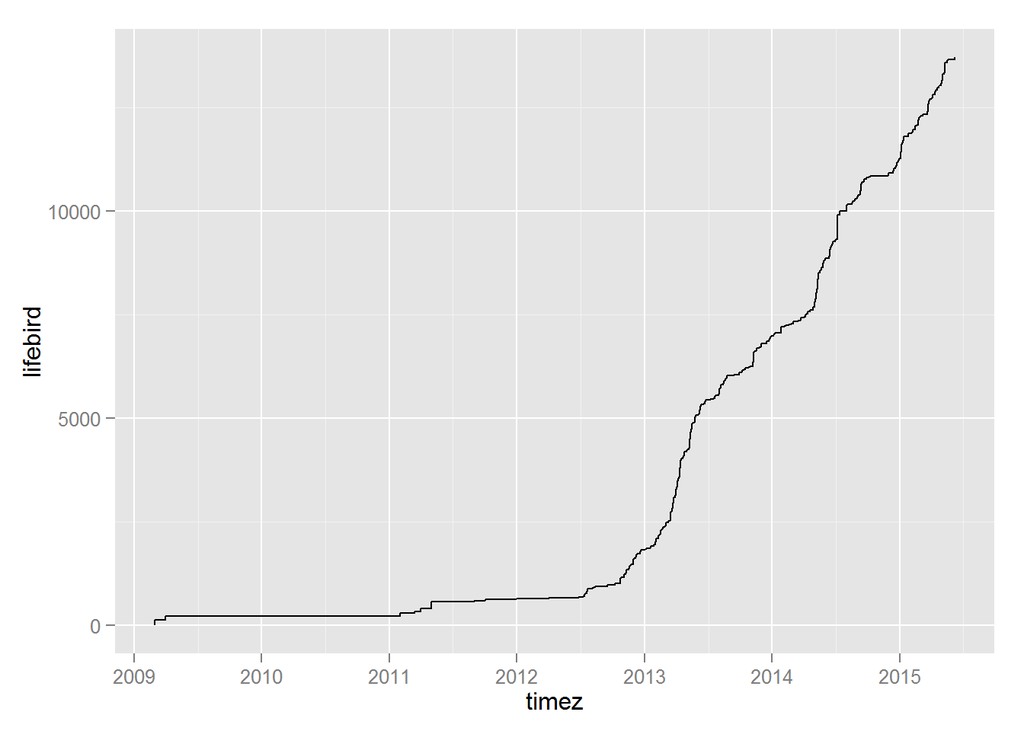

```r
myebird$timez<-as.POSIXct(timez,format='%m-%d-%Y %I:%M %p')

####which now makes it easy to sort
myebird<-myebird[order(myebird$commonname,myebird$timez),]
####now theres a couple of different ways to get what we want. But we essentially want the first observation
#I'm going to use aggregate

lifer <- myebird %>%  mutate(commonname=first(commonname))

lifer<- lifer %>% arrange(timez)

lifer$lifebird<-1:nrow(lifer)


###
ggplot(lifer,aes(timez,lifebird)) + geom_line()
```

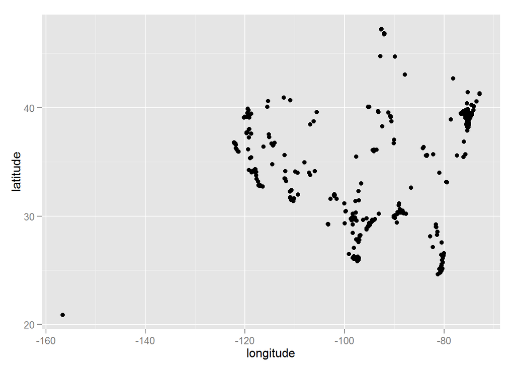

```r
ggplot(lifer,aes(longitude,latitude)) +geom_point()
```

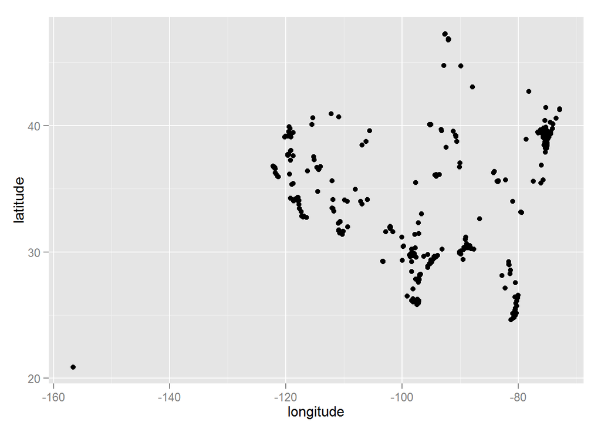

```r
ggplot(myebird,aes(longitude,latitude)) +geom_point()
```

# Effort correction

before we go comparing counts for a given species we need to think about the effort that went into creaeting those numbers

```r
myebird <- myebird %>% mutate(effortcount = count + distancetraveledkm)

summary(myebird$effortcount)
```

```
##    Min. 1st Qu.  Median    Mean 3rd Qu.    Max.    NA's
##   1.161   2.609   4.219  17.650  27.800 403.300    3567
```

ok, so this is all good and fine, but we have a lot of NAs which aren’t very informative.

how do we subset our data to get rid of these NA’s and their corresponding data?

```r
myebird <- myebird %>% filter(!is.na(effortcount))
```

tadah! NAs are gone.

there are functions which will do this, na.omit() to the entire data frame but when you only want to remove NAs from a particular column it is often easier to phrase it this way.

```r
data(gapminder)

gdat <- gapminder

colnames(gdat) <- tolower(colnames(gdat))

str(gdat)
```

```
## 'data.frame':    1704 obs. of  6 variables:
##  $ country  : Factor w/ 142 levels "Afghanistan",..: 1 1 1 1 1 1 1 1 1 1 ...
##  $ continent: Factor w/ 5 levels "Africa","Americas",..: 3 3 3 3 3 3 3 3 3 3 ...
##  $ year     : num  1952 1957 1962 1967 1972 ...
##  $ lifeexp  : num  28.8 30.3 32 34 36.1 ...
##  $ pop      : num  8425333 9240934 10267083 11537966 13079460 ...
##  $ gdppercap: num  779 821 853 836 740 ...
```

```r
dim(gdat)
```

```
## [1] 1704    6
```

Do not edit your raw data file. When doing initial management and cleaning you will likely create a new cleaned and ready to go file. Then when you go to do analysis you will work from this new clean file. There is no reason to break up this new data into lots of smaller data files. When you go to do some analysis read in the clean file, and subset it within R to do what you need to do. We’ve already talked about subsetting, use those skills to subset your data within R to accomplish your tasks, do not create a bajillion csv files.

### Wide vs Long Data

Wide format is where each unit (lets say a vegetation point) is a row, and each column is a variable (site, date, water depth, etc, etc)

(examples of wide data, since gapminder is already in long format)

```r
gdat %>% select(-pop,-gdppercap) %>% spread(year, lifeexp) %>% head()
```

```
##       country continent   1952   1957   1962   1967   1972   1977   1982
## 1 Afghanistan      Asia 28.801 30.332 31.997 34.020 36.088 38.438 39.854
## 2     Albania    Europe 55.230 59.280 64.820 66.220 67.690 68.930 70.420
## 3     Algeria    Africa 43.077 45.685 48.303 51.407 54.518 58.014 61.368
## 4      Angola    Africa 30.015 31.999 34.000 35.985 37.928 39.483 39.942
## 5   Argentina  Americas 62.485 64.399 65.142 65.634 67.065 68.481 69.942
## 6   Australia   Oceania 69.120 70.330 70.930 71.100 71.930 73.490 74.740
##     1987   1992   1997   2002   2007
## 1 40.822 41.674 41.763 42.129 43.828
## 2 72.000 71.581 72.950 75.651 76.423
## 3 65.799 67.744 69.152 70.994 72.301
## 4 39.906 40.647 40.963 41.003 42.731
## 5 70.774 71.868 73.275 74.340 75.320
## 6 76.320 77.560 78.830 80.370 81.235
```

```r
gdat %>% select(-lifeexp, -gdppercap) %>% spread(year, pop) %>% head()
```

```
##       country continent     1952     1957     1962     1967     1972
## 1 Afghanistan      Asia  8425333  9240934 10267083 11537966 13079460
## 2     Albania    Europe  1282697  1476505  1728137  1984060  2263554
## 3     Algeria    Africa  9279525 10270856 11000948 12760499 14760787
## 4      Angola    Africa  4232095  4561361  4826015  5247469  5894858
## 5   Argentina  Americas 17876956 19610538 21283783 22934225 24779799
## 6   Australia   Oceania  8691212  9712569 10794968 11872264 13177000
##       1977     1982     1987     1992     1997     2002     2007
## 1 14880372 12881816 13867957 16317921 22227415 25268405 31889923
## 2  2509048  2780097  3075321  3326498  3428038  3508512  3600523
## 3 17152804 20033753 23254956 26298373 29072015 31287142 33333216
## 4  6162675  7016384  7874230  8735988  9875024 10866106 12420476
## 5 26983828 29341374 31620918 33958947 36203463 38331121 40301927
## 6 14074100 15184200 16257249 17481977 18565243 19546792 20434176
```

```r
gdat %>% select(-pop, -lifeexp) %>% spread(year, gdppercap) %>% head()
```

```
##       country continent       1952      1957       1962       1967
## 1 Afghanistan      Asia   779.4453   820.853   853.1007   836.1971
## 2     Albania    Europe  1601.0561  1942.284  2312.8890  2760.1969
## 3     Algeria    Africa  2449.0082  3013.976  2550.8169  3246.9918
## 4      Angola    Africa  3520.6103  3827.940  4269.2767  5522.7764
## 5   Argentina  Americas  5911.3151  6856.856  7133.1660  8052.9530
## 6   Australia   Oceania 10039.5956 10949.650 12217.2269 14526.1246
##         1972       1977       1982       1987       1992       1997
## 1   739.9811   786.1134   978.0114   852.3959   649.3414   635.3414
## 2  3313.4222  3533.0039  3630.8807  3738.9327  2497.4379  3193.0546
## 3  4182.6638  4910.4168  5745.1602  5681.3585  5023.2166  4797.2951
## 4  5473.2880  3008.6474  2756.9537  2430.2083  2627.8457  2277.1409
## 5  9443.0385 10079.0267  8997.8974  9139.6714  9308.4187 10967.2820
## 6 16788.6295 18334.1975 19477.0093 21888.8890 23424.7668 26997.9366
##         2002       2007
## 1   726.7341   974.5803
## 2  4604.2117  5937.0295
## 3  5288.0404  6223.3675
## 4  2773.2873  4797.2313
## 5  8797.6407 12779.3796
## 6 30687.7547 34435.3674
```

```r
head(gdat)
```

```
##       country continent year lifeexp      pop gdppercap
## 1 Afghanistan      Asia 1952  28.801  8425333  779.4453
## 2 Afghanistan      Asia 1957  30.332  9240934  820.8530
## 3 Afghanistan      Asia 1962  31.997 10267083  853.1007
## 4 Afghanistan      Asia 1967  34.020 11537966  836.1971
## 5 Afghanistan      Asia 1972  36.088 13079460  739.9811
## 6 Afghanistan      Asia 1977  38.438 14880372  786.1134
```

Long format has an identification column (vegetation point id #) and two other columns, variable (the name of the variable “water depth, site, etc”) and one for value (the value for that vegetation point and that variable)

The advantage of long format data is it is easier to summarize and reform into graphs, tables, and to perform analysis.

### Data management and manipulation

```r
#creating an arbitary id variable to split back out. This could be anything, a date, a site name and point number, really anything

gdat <- gdat %>% mutate(id=paste("A", 1:nrow(gdat),sep="_"))

gathered <- gdat %>%  gather(id) %>% separate(id, into=c("letter","number"),sep="_")
```

### seperate

```r
# I realize this is an arbitary id value that we are trying to seperate but this is super useful for lots of things

gdat$id <- paste("A", 1:nrow(gdat),sep="_")

# how to split based on some kind of seperation character
gathered <- gdat %>% gather(id) %>% separate(id, into=c("letter","number"),sep="_")
# how to split based on the number of digits, can be one number or multiple
gatheredn <- gdat %>% gather(id) %>% separate(id, into=c("letter","line","num"), sep=c(1,2))

head(gathered)
```

```
##   letter number      id       value
## 1      A      1 country Afghanistan
## 2      A      2 country Afghanistan
## 3      A      3 country Afghanistan
## 4      A      4 country Afghanistan
## 5      A      5 country Afghanistan
## 6      A      6 country Afghanistan
```

```r
head(gatheredn)
```

```
##   letter line num      id       value
## 1      A    _   1 country Afghanistan
## 2      A    _   2 country Afghanistan
## 3      A    _   3 country Afghanistan
## 4      A    _   4 country Afghanistan
## 5      A    _   5 country Afghanistan
## 6      A    _   6 country Afghanistan
```

if you have a seperation character that you are willing to loose then using sep = “character” is the way to go, but that is not always the case

### merging/joining data frames

THIS IS SUPER POWERFUL (dplyr)

## merging with different columns

```r
# ok lets create some silly data that we want to merge with our gdat dataset
newdat<- data.frame(country=unique(gdat$country)[1:135], number=seq(1,135),by=1 , other="thinghere", new="otherthinghere")

## keeps everything from both gdat and newdat
ggdat <- full_join(gdat, newdat, by="country")
## keeps the rows of the left dataframe and adds those that match from the right
ggdatx <- left_join(gdat, newdat, by="country")
# keeps the rows of the right data frame and adds those that match from the left
ggdaty <- right_join(gdat, newdat, by="country")
nrow(ggdat) # so this is everything together
```

```
## [1] 1704
```

```r
nrow(ggdatx) # this has everything from gdat, so the same length as the one above
```

```
## [1] 1704
```

```r
nrow(ggdaty) # this one is shorter because it only kept the rows from newdat
```

```
## [1] 1620
```

```r
length(unique(ggdat$country))
```

```
## [1] 142
```

```r
length(unique(ggdatx$country))
```

```
## [1] 142
```

```r
length(unique(ggdaty$country))
```

```
## [1] 135
```

## merging with the same columns

```r
gdat1 <- gdat[1:1000,]
gdat2 <- gdat[999:1704,]

# rows that appear in both y and z

gdat1 %>% intersect(gdat2) %>% nrow()
```

```
## [1] 2
```

```r
# rows that appear in either y and/or z

gdat1 %>% union(gdat2) %>% nrow()
```

```
## [1] 1704
```

```r
# rows that appear in y but not z

gdat1 %>% setdiff(gdat2) %>% nrow()
```

```
## [1] 998
```

## summarising data

one of the big ways that we want to manipulate our data is to create tables so that we can look at our data in different ways. There are ways of creating publication ready tables in R, we’re not going to cover them today, as they also involve Latex, and that is another day (atleast) to itself

```r
mean <- gdat %>% group_by(country) %>% select(4:6) %>% summarise_each(funs(mean))

mean
```

```
## Source: local data frame [142 x 4]
##
##        country  lifeexp        pop  gdppercap
## 1  Afghanistan 37.47883 15823715.4   802.6746
## 2      Albania 68.43292  2580249.2  3255.3666
## 3      Algeria 59.03017 19875406.2  4426.0260
## 4       Angola 37.88350  7309390.1  3607.1005
## 5    Argentina 69.06042 28602239.9  8955.5538
## 6    Australia 74.66292 14649312.5 19980.5956
## 7      Austria 73.10325  7583298.4 20411.9163
## 8      Bahrain 65.60567   373913.2 18077.6639
## 9   Bangladesh 49.83408 90755395.3   817.5588
## 10     Belgium 73.64175  9725118.7 19900.7581
## ..         ...      ...        ...        ...
```

```r
median <- gdat %>% group_by(country) %>% select(4:6) %>% summarise_each(funs(median))

median
```

```
## Source: local data frame [142 x 4]
##
##        country lifeexp        pop  gdppercap
## 1  Afghanistan 39.1460 13473708.5   803.4832
## 2      Albania 69.6750  2644572.5  3253.2384
## 3      Algeria 59.6910 18593278.5  4853.8559
## 4       Angola 39.6945  6589529.5  3264.6288
## 5    Argentina 69.2115 28162601.0  9068.7844
## 6    Australia 74.1150 14629150.0 18905.6034
## 7      Austria 72.6750  7571521.5 20673.2530
## 8      Bahrain 67.3225   337688.5 18779.8016
## 9   Bangladesh 48.4660 86751356.0   703.7638
## 10     Belgium 73.3650  9839051.5 20048.9102
## ..         ...     ...        ...        ...
```

```r
sd <- gdat %>% group_by(country) %>% select(4:6) %>% summarise_each(funs(sd))

sd
```

```
## Source: local data frame [142 x 4]
##
##        country   lifeexp        pop gdppercap
## 1  Afghanistan  5.098646  7114583.5  108.2029
## 2      Albania  6.322911   828585.5 1192.3515
## 3      Algeria 10.340069  8613355.3 1310.3377
## 4       Angola  4.005276  2672280.6 1165.9003
## 5    Argentina  4.186470  7546609.0 1862.5832
## 6    Australia  4.147774  3915203.0 7815.4052
## 7      Austria  4.379838   437660.0 9655.2815
## 8      Bahrain  8.571871   210893.3 5415.4134
## 9   Bangladesh  9.028335 34711660.7  235.0796
## 10     Belgium  3.779658   520635.9 8391.1863
## ..         ...       ...        ...       ...
```

```r
n <- gdat %>% group_by(country) %>% select(4:6) %>% summarise_each(funs(length))

n
```

```
## Source: local data frame [142 x 4]
##
##        country lifeexp pop gdppercap
## 1  Afghanistan      12  12        12
## 2      Albania      12  12        12
## 3      Algeria      12  12        12
## 4       Angola      12  12        12
## 5    Argentina      12  12        12
## 6    Australia      12  12        12
## 7      Austria      12  12        12
## 8      Bahrain      12  12        12
## 9   Bangladesh      12  12        12
## 10     Belgium      12  12        12
## ..         ...     ... ...       ...
```

```r
se <- sd[,2:4] / sqrt(n[,2:4])

se <- cbind("country"=sd[,1], se)

head(se)
```

```
##       country  lifeexp     pop gdppercap
## 1 Afghanistan 1.471852 2053803   31.2355
## 2     Albania 1.825267  239192  344.2022
## 3     Algeria 2.984921 2486462  378.2619
## 4      Angola 1.156224  771421  336.5664
## 5   Argentina 1.208530 2178518  537.6814
## 6   Australia 1.197359 1130222 2256.1132
```